# Detrending AiREAS signals

M. Schipper

December 12, 2017

# Introduction

# Loading required packages

```r
library(ggplot2)
library(GGally)
library(reshape2)
library(chron)
library(lubridate)
library(splines)
```

# Set environment variables

```r
# set the current time zone to UTC
Sys.setenv(TZ = "UTC")
```

## Data

Reading data which has already been pre-cleaned in previous script.

```r
load(file =  "../data/dataframe08122017.bin")
```

## Additional cleaning

Removing the observations obtained on jan 1, 2017 00:00:00. These are not in 2016 and cause artefacts in visualizations. Besides that the month of observation is calculated from the dateTime variable.

```r
data <- subset(data,
  dateTime != as.POSIXct("2017-01-01 00:00:00", format = "%Y-%m-%d %H:%M:%S", tz="UTC"))
```

## Data preparation for detrending

For each measurement, calculate the hours since 2016-01-01 00:00:00 and the month in which the measurements were taken. For plotting issues, also reorder the levels of the station identifyers.

```r
# Take only relevant variables from data
data <- data[, c("dateTime", "stn_ID", "NO2")]
# Extract hours since jan 1, 2016 00:00:00 and month from dateTime variable
data <- within(data, {
  hours <- as.numeric((dateTime-as.POSIXct("2016-01-01 00:00:00",
    format = "%Y-%m-%d %H:%M:%S", tz="UTC"))/3600)
  # define month
  month <- month(dateTime)
  # reorder the measurement stations
  stn_ID <- factor(stn_ID,
    levels = levels(stn_ID)[order(as.numeric(unlist(regmatches(
      x = levels(stn_ID), m = gregexpr(
        pattern = "[[:digit:]]+",
        text = levels(stn_ID))))))])
})
```

### Reference signal

Take the $NO_2$ measurements of LML station NL10236 as the reference data. It is situated in the center of Eindhoven and we assume there is no linear decrease in its signal as result of degradation of the sensor.

```r
# Extract signal from station NL10236
data_ref <- subset(data, stn_ID == "NL10236", select = c(hours, NO2))
names(data_ref)[2] <- "ref"
# and merge with data, so that for each timepoint the reference signal is available
ref_data <- merge(data, data_ref, all = TRUE)
```

## Fit linear model

To `ref_data` we fit now linear model to describe for each AiREAS station the measured $NO_2^{AiR}$ signal by the reference signal $NO_2^{ref}$, an intercept and a linear slope of time and additional noise. The reference signal is used as an offset here, i.e. it appears in the model, but a coefficient is not estimated.
$$\forall {i|t_i\in 2016}: NO_2^{AiR}(t_i) = NO_2^{ref}(t_i) + \beta_0 + \beta_1t_i + \epsilon(t_i),$$
with $\forall {i|t_i\in 2016}\ \epsilon(t_i)$ are i.i.d. with $N(0, \sigma^2)$.

```r
mod.detrend <- with(ref_data, lm(NO2~ offset(ref) + hours*stn_ID))
```

## Detrend $NO_2$ signal

Based on this model we can make predictions of the AiREAS signal, as if there was no degradation of the sensor by setting $\beta_1=0$. The predicted AiREAS signal will then be:
$$\hat{NO_2^{AiR}}(t_i) = NO_2^{ref}(t_i) + \hat{\beta}_0 + \hat\epsilon(t_i),$$
where $\hat\beta_0$ and $\hat\epsilon(t_i)$ are the estimated intercept and residuals from the fitted linear model.

```r
ref_data <- within(ref_data, {
  # make predictions of original signal
  pred.NO2 <- predict(mod.detrend, newdata = ref_data)
  # make predictions of detrended signal, without residuals
  pred.NO2.detrend <- predict(mod.detrend, newdata = within(ref_data, hours<-0))
  # define the residuals
  errors <- NO2 - pred.NO2
  # add the residuals to the predictions, but do not detrend signal for LML stations
  NO2.detrend <- ifelse(test = grepl(pattern = "NL", x = stn_ID),
    yes = NO2, no = pred.NO2.detrend + errors)
  })
```

Graphically, it looks like this for AiREAS station 4:

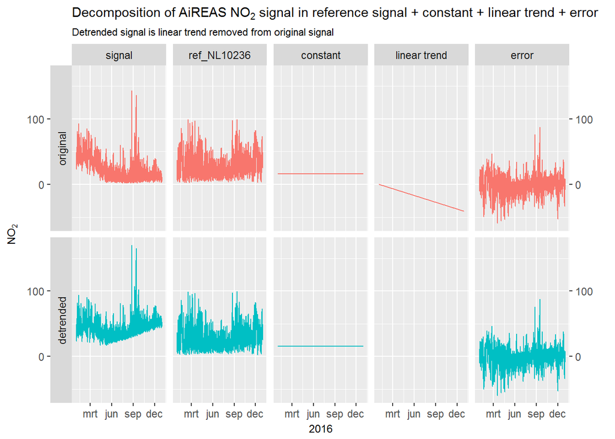

Now we visualize the detrended signals together with the original signals. For clearer distinction, plots are overlaid by smoothed versions of the monthly averages of the signals.

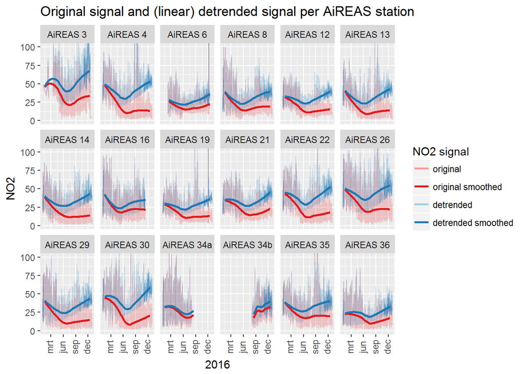

```r
# create monthly averages of the signals, for all stations
avg.signal.per.mnth <- aggregate(cbind(NO2, NO2.detrend)~month+stn_ID, data = ref_data, FUN = mean)
# create dateTime variable for plotting
avg.signal.per.mnth <- within(avg.signal.per.mnth, {
  dateTime <- as.POSIXct(
    paste0("2016-", formatC(month, width = 2, flag = "0"), "-15 00:00:00"),
    format = "%Y-%m-%d %H:%M:%S", tz="UTC")
})
# extract colors from RColorBrewer package
cols <- RColorBrewer::brewer.pal(9, "Paired")[c(5, 6, 1, 2)]
# define a function that adds "AiREAS" to use in the labeller argument of facet_wrap
presetter <- function(string, prefix = "AiREAS ") paste0(prefix, string)

detrend_plot <- ggplot(
  data = subset(ref_data, !grepl(pattern = "NL", x = stn_ID)),
  mapping = aes(x = dateTime, y = NO2)) +
  geom_line(mapping = aes(colour = "col1", alpha = "original")) +
  geom_line(mapping = aes(y = NO2.detrend, colour = "col3", alpha = "original")) +
  geom_smooth(data = subset(avg.signal.per.mnth, !grepl(pattern = "NL", x = stn_ID)),
    mapping = aes(colour = "col2", alpha = "smoothed"), se = FALSE)  +
  geom_smooth(data = subset(avg.signal.per.mnth, !grepl(pattern = "NL", x = stn_ID)),
    aes(y = NO2.detrend, colour = "col4", alpha = "smoothed"), se = FALSE)  +
  coord_cartesian(ylim = c(0, 100)) +
  facet_wrap(~stn_ID, nrow = 3, labeller = as_labeller(presetter)) +
  scale_x_datetime(date_breaks = "3 months", date_labels = "%b") +
  scale_colour_manual(name = "NO2 signal", values = cols[c(2, 2, 4, 4)],
    labels = c("original", "original smoothed", "detrended","detrended smoothed")) +
  scale_alpha_discrete(name = "", range = c("original" = .2, "detrended" = 1)) +
  guides(alpha = "none") +
  guides(colour = guide_legend(override.aes = list(colour = cols))) +
  labs(x = "2016",
    title = "Original signal and (linear) detrended signal per AiREAS station") +
  theme(axis.text.x = element_text(angle = 90, vjust = 0.3))
print(detrend_plot)
```

```r
# and save plot to disc as jpeg
jpeg(filename = "../figures/detrended signals.jpeg", height = 7, width = sqrt(2)*7, units = "in",
  res = 300)
print(detrend_plot)
dev.off()
```

## Saving detrended signals

The detrended signals are added to the lastest version of the original data. Subsequently the extended data frame is saved to disc as R binary and csv.

```r
# extract relevant variables
df.to.merge <- subset(ref_data, select = c(dateTime, stn_ID, NO2.detrend))
# rename corrected signal
names(df.to.merge)[3] <- "NO2_corrected"

# load latest version of data (stored in object df)
load("../data/dataframe3_15u00.RData")

# merge detrended signal with df
df.corrected <- merge(df, df.to.merge, all.x = TRUE)

# store merged data on disc as R binary
save(df.corrected, file = "../data/dataframe19-12-2017_11u25.RData")
# store merged data on disc as .csv
write.csv(df.corrected, file = "../data/dataframe19-12-2017_11u25.csv")
```